# Advanced Visualizations

Seminar: Data Visualisation: Principles, Practices and Applications

Julia Schulte-Cloos

University of Marburg

December 2, 2025

✉️ julia.schulte-cloos@uni-marburg.de

# Spatial Visualizations

## What are geo-data?

…and in which contexts play geo-data a role in the field of social sciences?

> data characterised by a geographic location or referring to a geographic location 🌍

#### Types of geodata

**[1] absolute geo-data**

- GPS data 📍
- projection via a coordinate reference system (CRS) 🗺️

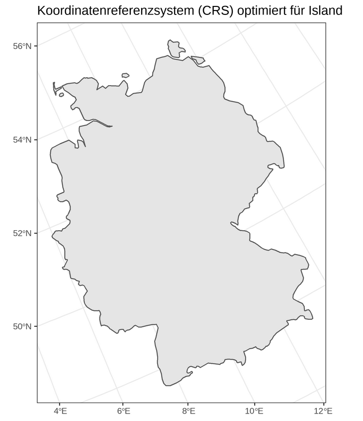

Germany optimised for Islandic CRS

## What are geo-data?

#### Types of geodata

**[1] absolute geo-data**

- GPS data 📍
- projection via a coordinate reference system (CRS) 🗺️

**[2] relative geo-data**

- “at home” 🏠
- dominating the *human* use of geo-data 💬
- $\rightarrow$ need to be connected to other types of geo-data

**Structured and unstructured geo-data**

- **structured**: organization of the data facilitates processing by computer (e.g. shapefile format of vector data) 👨‍💻️
- **unstructured**: geo-information must first be extracted using methods such as geocoding, geotagging or geoparsing 🕵️

## Import of spatial data: `sf` objects

- Overview
- Example
- Output
- “**S**imple **F**eatures” objects are `data.frames`
- **additional dimension to each observation**: certain type of geoinformation (`geometry` column), e.g.
  - points (described by *one* pair of coordinates) 🔵
  - Lines (described by *two* coordinate pairs) ➖
  - Polygons (described by at least three coordinate pairs)
  - “Regular Grid” (described by a pair of coordinates for the center of gravity + grid size)

```r
# Create a sub-directory
directory_name <- "./data"
ifelse(dir.exists(directory_name),
        "Directory exists",
        dir.create(directory_name)
        )

# download shapefile of electoral districts during Federal Election 2021 (zip file)
temporary_file <- tempfile()
bundeswahlleiter_link <- "https://www.bundeswahlleiter.de/dam/jcr/8794eadd-fc0c-4889-a233-2ccae3b4cf5e/btw21_geometrie_wahlkreise_geo_shp.zip"
download.file(bundeswahlleiter_link, temporary_file)
unzip(zipfile = temporary_file, exdir = paste0(directory_name))
unlink(temporary_file)
```

```r
electoral_districts_shp <- read_sf("./data/Geometrie_Wahlkreise_20DBT_geo.shp")
head(electoral_districts_shp)


# which crs?
sf::st_crs(electoral_districts_shp)
```

```
Simple feature collection with 6 features and 4 fields
Geometry type: MULTIPOLYGON
Dimension:     XY
Bounding box:  xmin: 8.278556 ymin: 53.70766 xmax: 10.72597 ymax: 55.05838
Geodetic CRS:  WGS 84
# A tibble: 6 × 5
  WKR_NR WKR_NAME                    LAND_NR LAND_NAME                  geometry
   <dbl> <chr>                       <chr>   <chr>            <MULTIPOLYGON [°]>
1      1 Flensburg – Schleswig       01      Schleswi… (((9.708774 54.83053, 9.…
2      2 Nordfriesland – Dithmarsch… 01      Schleswi… (((8.630545 54.48889, 8.…
3      3 Steinburg – Dithmarschen S… 01      Schleswi… (((8.693724 54.04566, 8.…
4      4 Rendsburg-Eckernförde       01      Schleswi… (((9.866104 54.44812, 9.…
5      5 Kiel                        01      Schleswi… (((10.18877 54.41108, 10…
6      6 Plön – Neumünster           01      Schleswi… (((10.64299 54.34371, 10…
```

```
Coordinate Reference System:
  User input: WGS 84
  wkt:
GEOGCRS["WGS 84",
    DATUM["World Geodetic System 1984",
        ELLIPSOID["WGS 84",6378137,298.257223563,
            LENGTHUNIT["metre",1]]],
    PRIMEM["Greenwich",0,
        ANGLEUNIT["degree",0.0174532925199433]],
    CS[ellipsoidal,2],
        AXIS["latitude",north,
            ORDER[1],
            ANGLEUNIT["degree",0.0174532925199433]],
        AXIS["longitude",east,
            ORDER[2],
            ANGLEUNIT["degree",0.0174532925199433]],
    ID["EPSG",4326]]
```

## Visualisation of spatial data

- Overview
- Example
- Output
- “normal” dataframe
- additional column: `geometry`
- spatial data can be easily visualized with `ggplot`
- the corresponding ggplot layer is called `geom_sf`
- ✔️ using geographical information, we can link a variety of different (unrelated) data sources

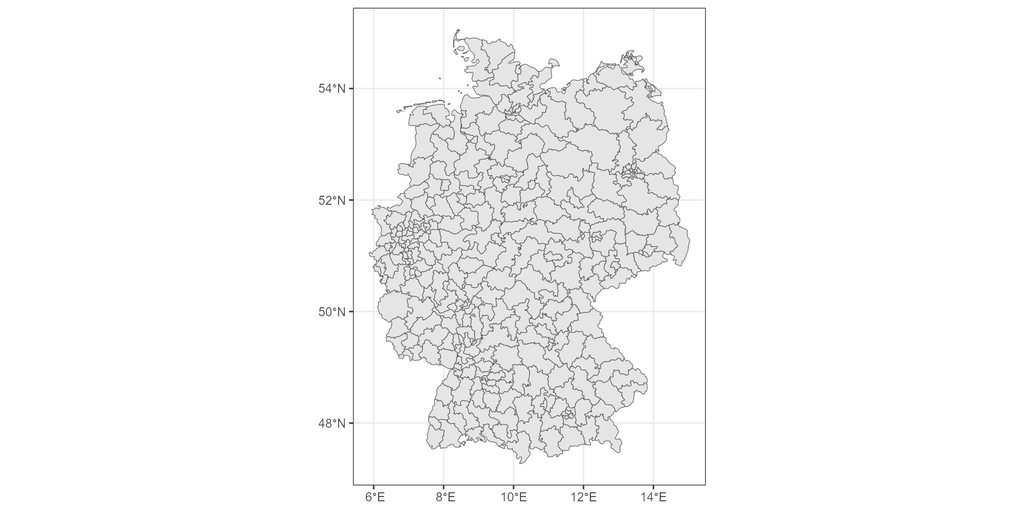

```r
ggplot(data = electoral_districts_shp) +
    geom_sf() +
    theme_bw()
```

## Linking spatial data to other data sources

- Overview
- Example
- Output
- any data that shares an identifier with the sf data can be linked
- identifiers can carry implicit spatial dimension, e.g.:
  - country name
  - state names
  - electoral districts
- BUT: just because data can be mapped does not always mean it should be mapped?
- [How to avoid being fooled by maps](https://www.bloomberg.com/news/articles/2015-06-25/how-to-avoid-being-fooled-by-bad-maps)

```r
electoral_data_url <- "https://www.bundeswahlleiter.de/dam/jcr/2a90d988-7063-48af-b265-dfb9fa14f7e3/btw21_kerg2.csv"
electoral_data <- read_csv2(electoral_data_url,
                            skip = 9) %>%
  filter(Gebietsart == "Wahlkreis") %>%
  filter(Stimme == 2) %>%
  filter(Gruppenname == "AfD") %>%
  rename(electoral_district_id = Gebietsnummer,
         party = Gruppenname,
         afd_vote_share = Prozent) %>%
  select(electoral_district_id,
         party,
         afd_vote_share)

head(electoral_data)

# generate character id to match the data to the shape file
electoral_districts_shp <- electoral_districts_shp %>%
  mutate(electoral_district_id = str_pad(
    as.character(WKR_NR),
    pad = "0",
    width = 3,
    side = "left"
  ))

# left_join (!) to shape file
electoral_districts_shp <- electoral_districts_shp %>%
    left_join(.,
        electoral_data,
       by = c("electoral_district_id")
       )


# plot the vote share of AfD
afd_vote_plot <- ggplot(data = electoral_districts_shp) +
  geom_sf(aes(fill = afd_vote_share)) +
  theme_void() +
  scale_fill_distiller(trans = "reverse",
                       name = "AfD Vote Share")
afd_vote_plot
```

```
# A tibble: 6 × 3
  electoral_district_id party afd_vote_share
  <chr>                 <chr>          <dbl>
1 001                   AfD             5.78
2 002                   AfD             6.10
3 003                   AfD             8.37
4 004                   AfD             6.56
5 005                   AfD             4.94
6 006                   AfD             7.35
```

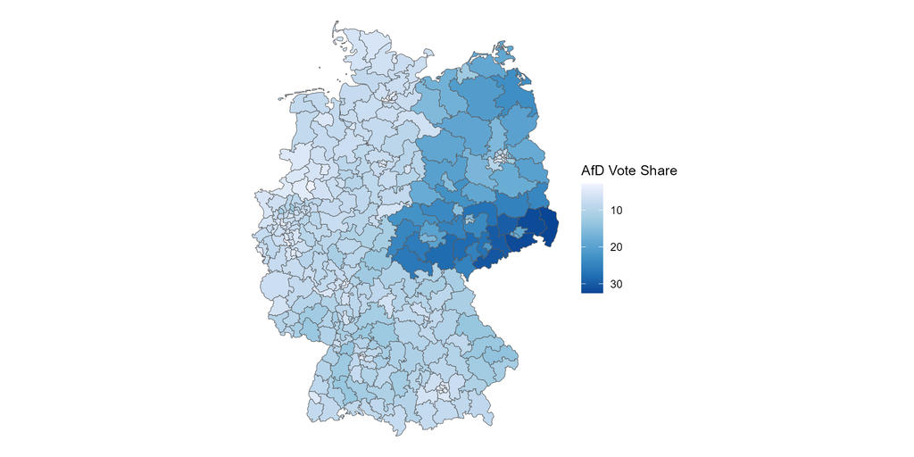

## Contrasting different spatial distributions

- Overview
- Example
- Output
- use `patchwork` to show two spatial distributions side-by-side

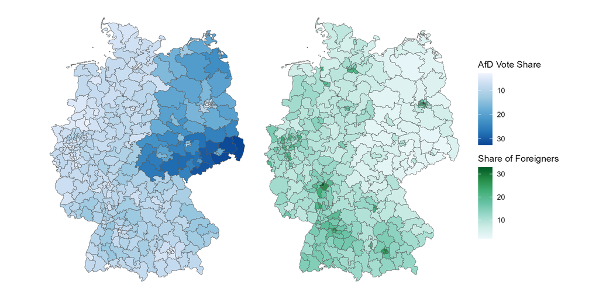

```r
# add the official socio-demographic information for the electoral districts
structural_data_url <- "https://www.bundeswahlleiter.de/dam/jcr/b1d3fc4f-17eb-455f-a01c-a0bf32135c5d/btw21_strukturdaten.csv" # nolint
structural_data <- read_csv2(structural_data_url,
                           skip = 8) %>%
  rename(electoral_district_id = `Wahlkreis-Nr.`,
         electoral_district_name = `Wahlkreis-Name`,
         foreigner_share = `Bevölkerung am 31.12.2019 - Ausländer/-innen (%)`) %>%
  select(electoral_district_id,
         electoral_district_name,
         foreigner_share) %>%
  # keep only observations that relate to electoral districts
  filter(!str_detect(electoral_district_name,
                     pattern = "[Ii]nsgesamt"))


# add the share of foreigners to the shape file
electoral_districts_shp <- electoral_districts_shp %>%
  left_join(.,
            structural_data,
            by = c("electoral_district_id")
  )

# plot the share of foreigners
foreigner_share_plot <- ggplot(data = electoral_districts_shp) +
  geom_sf(aes(fill = foreigner_share)) +
  theme_void() +
  scale_fill_distiller(direction = 1,
                       palette = "BuGn",
                       name = "Share of Foreigners"
                       )
foreigner_share_plot


# show both plots side-by-side
afd_vote_plot + foreigner_share_plot +
    plot_layout(guides = 'collect')
```

# Application 1

## Application 1

**Work through the `03_advanced_spatial_exercises.qmd` together with your neighbor, running the code yourself and trying to understand the different steps in creating each map.**

➡️ Consult the excellent book [Fundamentals of Data Visualisation](https://clauswilke.com/dataviz/) by Claus Wilke to develop an intuition of good and bad practices when visualising spatial data.

➡️ BONUS: can you turn one of the maps included in the worksheet into a cartogramm?

# Text and Annotations

## Why Annotate?

- Overview
- Example
- Output
- data visualization is not just about plotting data, but about communication
- a plain plot shows what is in the data, but it doesn’t offer any interpretation (forces the reader to do all the work).
- an annotated plot guides your reader, by highlighting key findings, providing context, and turning a simple ‘chart’ into a compelling ‘insight’.
- we use annotations to:
  - Highlight important points or groups (e.g., outliers).
  - Explain anomalies or trends.
  - Label key features directly.

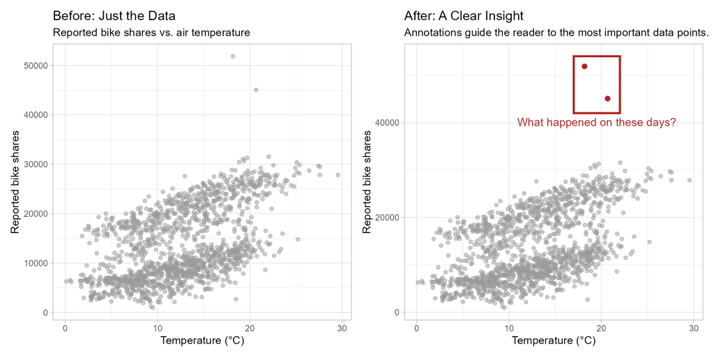

```r
# Just the raw data. What are we supposed to see?
plot_before <- ggplot(
    bikes,
    aes(x = temp, y = count)
  ) +
  geom_point(alpha = .5, color = "grey60") +
  theme_light() +
  labs(
    title = "Before: Just the Data",
    subtitle = "Reported bike shares vs. air temperature",
    x = "Temperature (°C)",
    y = "Reported bike shares"
  )

# Same data, but now with a story.
plot_after <- ggplot(
    bikes,
    aes(x = temp, y = count)
  ) +
  # 1. De-emphasize the unimportant points
  geom_point(alpha = .5, color = "grey60") +
  # 2. Highlight the important points
  geom_point(
    data = filter(bikes, count > 40000),
    color = "firebrick",
    size = 2
  ) +
  # 3. Add a rectangle to group the outliers
  annotate(
    geom = "rect",
    xmin = 17,
    xmax = 22,
    ymin = 42000,
    ymax = 54000,
    color = "firebrick",
    fill = NA,
    linewidth = 1
  ) +
  # 4. Add text to explain the highlight
  annotate(
    geom = "text",
    x = 19.5,
    y = 41000, # Positioned just below the box
    label = "What happened on these days?",
    color = "firebrick",
    size = 4,
    vjust = 1
  ) +
  theme_light() +
  labs(
    title = "After: A Clear Insight",
    subtitle = "Annotations guide the reader to the most important data points.",
    x = "Temperature (°C)",
    y = "Reported bike shares"
  )

# Use patchwork to show side-by-side
plot_before + plot_after
```

## The Text & Annotation Toolkit

- [`ggrepel`](https://ggrepel.slowkow.com/) ➡️ For clean, non-overlapping labels. It intelligently “repels” text from data points and other labels.
- [`ggtext`](https://wilkelab.org/ggtext/) ➡️ For rich text styling. It lets you use Markdown and HTML to add **bold**, *italics*, and colors to your titles, subtitles, and labels.
- [`ggforce`](https://ggforce.data-imaginist.com/index.html) ➡️ For highlighting and enclosing groups of points with `geom_mark_hull`, `geom_mark_rect`, etc.
- [`geomtextpath`](https://allancameron.github.io/geomtextpath/articles/geomtextpath.html) ➡️ For placing text labels directly onto a line, following its curve.

# Hands On: Worksheet

# Application 2

## Application 2

#### Option A

➡️ **Rely on some data that is relevant to your field and subject of your PhD. Try to visualize some of the data in spatial terms. Try to use different chloropleths to fill the respective polygons.**

#### Option B

➡️ **Try to style your labels and scales from your previous visualisations and add some special textual elements.**

# Questions? 🙋 🙋‍♂️

# Thanks for your attention.

[figure not shown]